# Asylentscheidungen in Europa

ynux

August, 2018

### Die Asyldaten von Eurostat

In diesem Artikel werfen wir einen Blick auf die Erstentscheidungen von den afghanischen Fü?chtlingen in Europa.

Eurostat ist das statistische Amt der Europäischen Union. Es sammelt und veröffentlicht Daten zu vielen Themen, auch zu Asyl und Migration.

Besonders interessant sind die Erstentscheidungsdaten. Das Datenset trägt den hübschen Namen `migr_asydcfsta`: “Erstinstanzliche Entscheidungen über Asylanträge nach Staatsangehörigkeit, Alter und Geschlecht Jährliche aggregierte Daten”.

Für Deutschland sind das die Entscheidungen des Bundesamts für Migration und Flüchtlinge (BAMF). Die Bezeichnung “erstinstanzlich” ist hier etwas verwirrend, denn die erste juristische Instanz ist hier das Verwaltungsgericht, dass über Klagen gegen die Entscheidung des BAMF entscheidet.

Zurück zu unseren Daten. Sie decken die Jahre 2008 bis 2017 ab (Stand August 2018). Man kann sie von der Website von Eurostat herunterladen. Allerdings sind sie sind ziemlich groß - 85 Mb und 13 Millionen Werte. Mit Excel kommt man da nicht weiter, deswegen benutzt dieser Artikel die Statistiksprache `R`.

Was bieten uns die Daten?

Wir konzentrieren uns im Folgenden auf: * die Entscheidungen (“`values`”) * das Herkunftsland Afghanistan (“`citizen`”) * das Jahr 2017 * die europäischen Länder (“`geo`”), für die es genug Daten gibt, um damit sinnvolle Analysen zu machen. Zur Abgrenzung von den Herkunftsländern heißen sie im Folgenden “Antragsland”.

```r
cutoff=1000
major_geo_total=filter(migr_asydcfsta, values > cutoff, time == "2017-01-01", decision == "TOTAL", sex == "T", age == "TOTAL", citizen == "AF", geo != "EU28") %>%
  select(geo,values) %>%
  arrange(desc(values))
```

### Die Anzahl Entscheidungen pro Antragsland

Länder mit mehr als 1000 Entscheidungen zu Asylanträgen aus Afghanistan

| geo | values |
| --- | --- |
| TOTAL | 184265 |
| DE | 109732 |
| SE | 25155 |
| AT | 17730 |
| FR | 7516 |
| BE | 5160 |
| CH | 3094 |
| EL | 2134 |
| IT | 1972 |
| UK | 1909 |
| NL | 1894 |
| HU | 1800 |
| NO | 1518 |
| BG | 1388 |
| DK | 1349 |
| FI | 1334 |

Wenn Du an diesen Zahlen zweifelst und sie selber überprüfen willst, finde ich das genau richtig. Misstrauen in Daten ist gut. Eurostat hat einen Data Explorer unter eurostat -> Daten -> Datenbank -> Datenbank nach Themen -> Bevölkerung und soziale Bedingungen -> Asyl und Gesteuerte Migration, oder Du googelst nach “migr_asydcfsta”.

Die Daten zeigen Ländercodes, die vollen Bezeichnungen sind hier:

Ländercodes der wichtigsten Antragsländer

| code | label |
| --- | --- |
| BE | Belgien |
| BG | Bulgarien |
| DK | Dänemark |
| DE | Deutschland (bis 1990 früheres Gebiet der BRD) |
| EL | Griechenland |
| FR | Frankreich |
| IT | Italien |
| HU | Ungarn |
| NL | Niederlande |
| AT | Österreich |
| FI | Finnland |
| SE | Schweden |
| UK | Vereinigtes Königreich |
| NO | Norwegen |
| CH | Schweiz |

Diese Zahlen sind für mich schon überraschend. Die anderen 17 Länder sind zusammen für weniger als 600 Entscheidungen verantwortlich:

```
## [1] 580
```

Eine Visualisierung von den Entscheidungen zu Afghanistan im Jahr 2017:

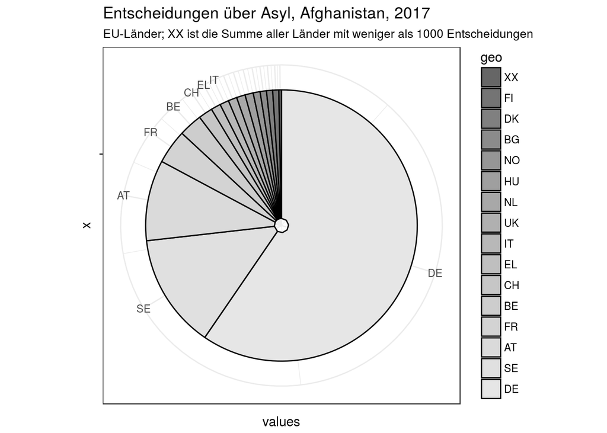

Überraschend finde ich auch, dass Spanien nicht in unserer Analyse vertreten ist, weil es nicht auf 1000 Entscheidungen kommt. Deutschland kommt auf fast 60% aller Entscheidungen. Nun ist Deutschland auch das bevölkerungsreichste Land der EU. Wenn wir uns die EU-Länder mit mehr als 8 Mio Einwohnern anschauen und neben ihre Einwohnerzahl (geteilt durch 1000) die Anzahl Entscheidungen stellen, erhalten wir dieses Bild:

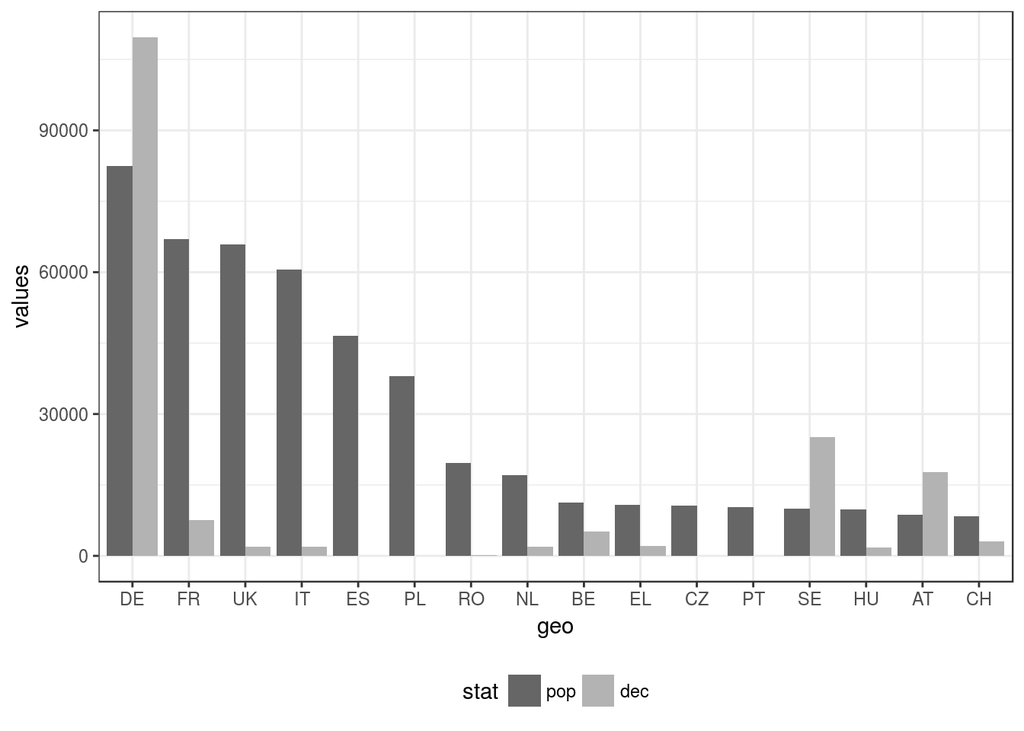

In den großen Ländern außer Deutschland gab es auffallend wenig Entscheidungen. In den kleinen Ländern Schweden und Österreich dagegen überproportional viele. Das waren Vorbetrachtungen, um zu verstehen, welche Antragsländer wir sinnvoll untersuchen können. Jetzt schauen wir uns die Entscheidungen an.

## Die Entscheidungen: GENCONV + HUMSTAT + SUB_PROT + TEMP_PROT + REJECTED = TOTAL_POS + REJECTED = TOTAL

Entscheidungscodes

| code | label |
| --- | --- |
| TOTAL_POS | Gesamtzahl der positiven Beschlüssen |
| GENCONV | Genfer Abkommen Rechtsstatus |
| HUMSTAT | Humanitärer Rechtsstatus |
| REJECTED | Abgelehnt |
| SUB_PROT | Subsidiärer Schutz |
| TEMP_PROT | Vorübergehender Schutz |

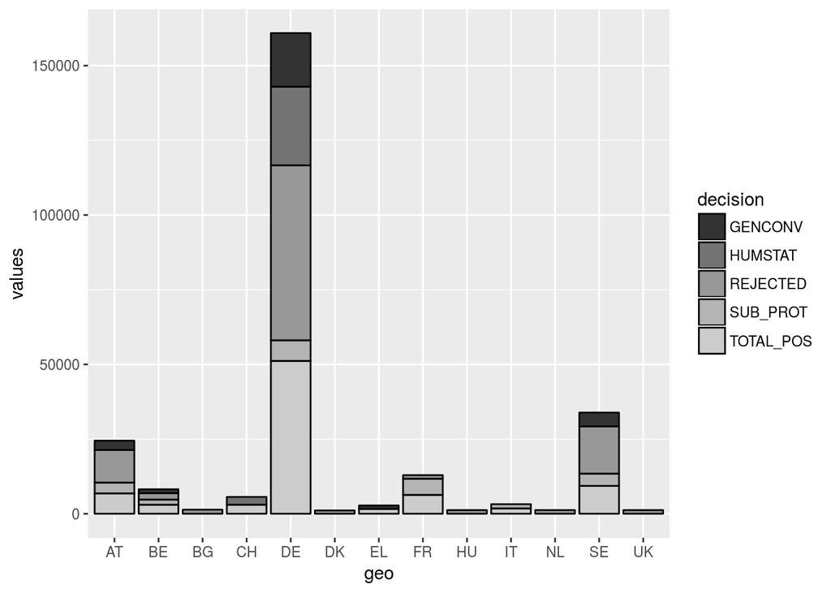

```r
dec_bar <- ggplot(filter(major_geo, decision != "TOTAL")) + geom_col(aes(x=geo, y=values, fill=decision), colour="black") + scale_fill_grey()
dec_bar
```